# Examples

Run the code, draw standard plots, and explore APC methods

Published

September 28, 2026

Modified

September 28, 2026

← Back to home

## Examples

Practice with real cancer surveillance data from the US Surveillance, Epidemiology, and End Results (SEER) program. Choose an example below. Each one has a short description. Live scripts (`.mlx`) hold the code, so you can run them in MATLAB Online. Live scripts marked “coming soon” are still being prepared.

## Data and Lexis diagrams

These examples use the built-in SEER datasets. Start with **Example data**, then continue in order.

### Example data

MATISSE includes 16 example datasets from the US Surveillance, Epidemiology, and End Results (SEER) program. A **Lexis diagram** displays rates by age and calendar period. Start with example 16 to explore the workflow before using your own data. Run the code below to load the data and fill zero cells. Set `DELTA` to 2 or 5 to combine age and period intervals when the data are sparse.

```matlab
Example = 16;      % 1x1 age-by-period Lexis diagram, e.g. "F melanoma NHW"
DELTA   = 1;        % chunk to 2x2 or 5x5 age/period blocks if the data are sparse

r = ratesdata(Example);
switch DELTA
    case 1
        R0 = r;
    case 2
        R0 = chunk(r, 'AgeBlock', 2, 'PerBlock', 2);
    case 5
        R0 = chunk(r, 'AgeBlock', 5, 'PerBlock', 5);
end

R = fill(R0);   % add a small value to any zero cells
disp(R)
```

### Visualizing a Lexis diagram

**Video:** [Watch Visualizing a Lexis diagram on YouTube](https://www.youtube.com/watch?v=dzQgEBVj48o) (43 sec).

Two plots help you explore the same data. A **heat map** uses color to show the rates; a **3-D surface** shows log rates. Run the Example data section first to create `R`. Then run this code: `pcolor(R)` draws the heat map, and `surf(R)` draws the surface.

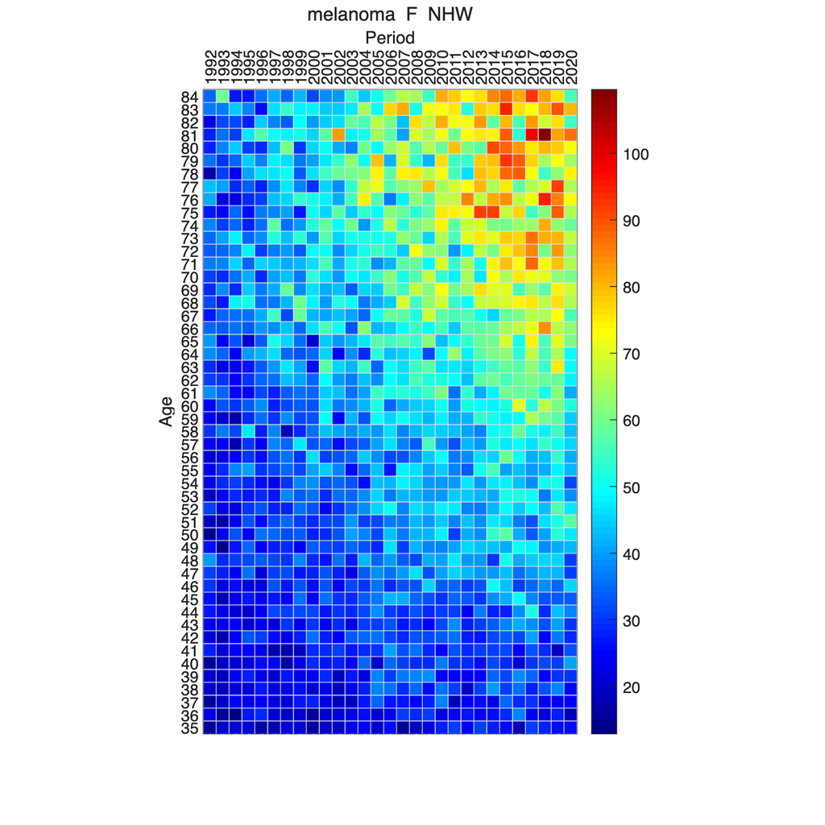

`melanoma F NHW`, 1992–2020 SEER rates per 100,000 — `pcolor` heat map

```matlab
figure('Position', [0 0 700 700])
pcolor(R)

figure('Position', [0 0 700 700])
surf(R)
```

[output not shown]

Graphics settings can make patterns easier to see. Run the code below to compare the surface on the left with a heat map on the right. The heat map uses the `nepal` color scheme. Change one option at a time and inspect the result.

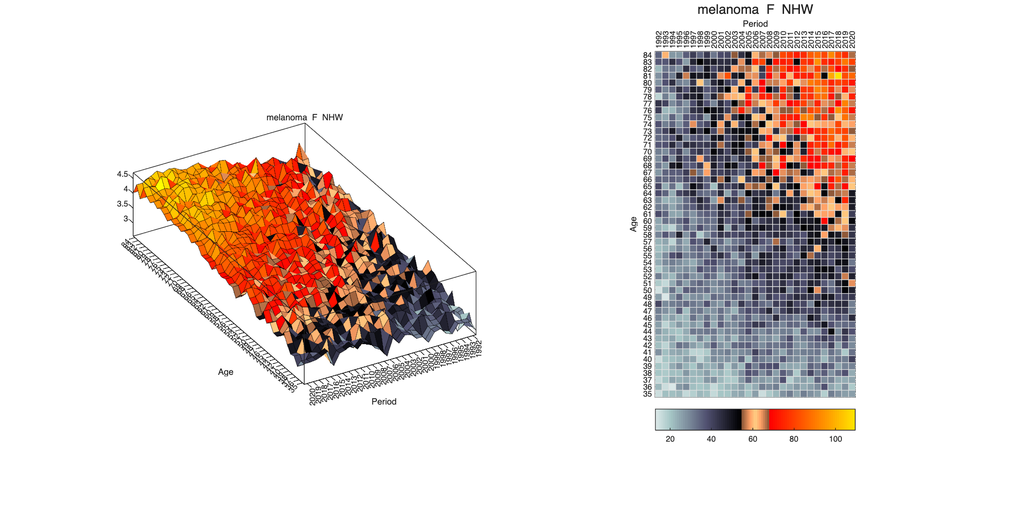

Log-rate surface vs. heat map, same Lexis diagram

```matlab
subplot(1, 2, 1)
surf(R)
colormap nepal
colorbar off
shading faceted

subplot(1, 2, 2)
pvp1 = ego('class', 'rates', 'method', 'pcolor');
pvp1.colormap  = 'nepal';
pvp1.colorbar  = 'southoutside';
pcolor(R, pvp1)
```

A **property-value pair** names a graphics setting and gives its value. The `go` options store these settings. Use `ego` to copy a plot method’s default settings, then edit the copy. MATISSE includes a 54-color line palette called `clarinet`. It also includes the `africa` and `nepal` color schemes, alongside MATLAB’s built-in choices.